# Biodiversity Surveys: Plant and Bird Communities in the Pomona College Wash

Marc Los Huertos

EA030 · Compiled 2026-04-23

EA030 — RTricks — Activity 15

# Biodiversity Surveys: Plants & Birds in the Pomona College Wash

**Prof. Marc Los Huertos** • Pomona College • Environmental Analysis

← Back to RTricks

#### 🎯 Learning Outcomes

1. Build and validate a **species × site matrix** from transect survey data.
2. Calculate and compare species richness, Shannon diversity, and Simpson’s index across parcels.
3. Construct and interpret **rarefaction curves** to account for unequal sampling effort.
4. Visualize community composition with stacked bar charts and explain what they reveal.
5. Run a basic **NMDS ordination** with `vegan` and interpret the resulting plot.
6. Use permutational MANOVA (PERMANOVA) to test whether plant communities differ among parcels.
7. Connect your results to broader questions about disturbance, restoration, and riparian ecology.

> **What this project covers.** The Pomona College Wash is a restored riparian corridor on the edge of campus — a patchwork of native bunchgrasses, willows, and mulefat interspersed with invasive annual grasses and ruderal forbs. This project has two parts. In **Part I** you analyze simulated vegetation transect data to ask: *how similar are plant communities across different parcels of the Wash, and is any one parcel substantially more diverse or distinct?* In **Part II** you analyze point-count bird survey data from the same parcels to ask: *which bird species use the Wash, how does avian diversity relate to vegetation structure, and do plant and bird communities track each other across the disturbance gradient?* Together the two surveys illustrate how the same core toolkit — richness, rarefaction, diversity indices, and NMDS ordination — applies to very different kinds of biodiversity data.

## The Analytical Pipeline

Plant community data require a specific sequence of steps before any comparative statistics can be run. The diagram below maps the full workflow.

Stage 1

Build the Matrix

Aggregate raw transect records into a species × site abundance matrix — the standard input for all community analyses.

Stage 2

Explore & QA

Check for data entry errors, confirm total cover, inspect the frequency distribution of species detections.

Stage 3

Richness & Diversity

Count species per parcel, compare Shannon H’ and Simpson 1−D indices, visualize with error bars.

Stage 4

Rarefaction

Standardize for effort. Rarefy to a common sample size so richness comparisons are not confounded by transect count.

Stage 5

Composition

Stacked bars and rank-abundance plots reveal which species dominate each parcel and which are rare.

Stage 6

Ordination

NMDS reduces multivariate community data to two dimensions. PERMANOVA tests whether parcels differ significantly.

**📄 Study system.** The data in this module are **simulated** but ecologically realistic. Species identities, cover values, and community structure are all modeled on published vegetation surveys from the Bernard Field Station, a 117-acre preserve adjacent to the Claremont Colleges. The Wash itself is a ~1 km restored drainage corridor managed by Pomona College’s Sustainability office. If you are running this analysis as part of a field campaign, you can swap in your own `transect_data.csv` at the import step — the rest of the pipeline is unchanged.

## 1. Setup & Data Generation

### 1.1 Packages

```r
# Install once (remove the # to uncomment, run, then re-comment):
# install.packages(c("tidyverse", "vegan", "knitr", "kableExtra",
#                    "ggrepel", "RColorBrewer", "viridis"))

library(tidyverse)     # wrangling + ggplot2
library(vegan)         # diversity, rarefaction, ordination
library(knitr)         # tables in RMarkdown
library(kableExtra)    # styled tables
library(ggrepel)       # non-overlapping species labels on ordination
library(RColorBrewer)  # color palettes
library(viridis)       # colorblind-safe sequential palette
```

**⚙️ What is `vegan`?**  
`vegan` (Oksanen et al. 2022) is the primary R package for community ecology. It implements essentially every diversity index, rarefaction algorithm, distance measure, and ordination technique in the ecological literature. The name is a historical joke — “vegetation analysis” — not a dietary statement.

### 1.2 Simulated transect data

The Wash is divided into **10 parcels** (P01–P10), each surveyed with **20 transects** of 50 m. Along each transect, observers recorded the percent cover (to the nearest 5%) of every plant species rooted within a 1-m belt. The species list is drawn from Bernard Field Station surveys and includes native bunchgrasses, native shrubs, native forbs, and invasive annual grasses.

```r
set.seed(2024)

# ── Species pool ──────────────────────────────────────────────────────────────
# 28 species: native shrubs, native grasses, native forbs, non-native grasses,
# non-native forbs.  Modeled on BFS plant lists.
species_pool <- tibble(
  species  = c(
    # Native shrubs / trees
    "Baccharis salicifolia",    # mule fat        – dominant riparian shrub
    "Salix laevigata",          # red willow
    "Sambucus nigra",           # elderberry
    "Artemisia californica",    # California sagebrush
    "Encelia californica",      # bush sunflower
    "Malosma laurina",          # laurel sumac
    # Native bunchgrasses
    "Nassella pulchra",         # purple needlegrass  – CA state grass
    "Nassella lepida",          # foothill needlegrass
    "Muhlenbergia rigens",      # deer grass
    "Elymus condensatus",       # giant wild rye
    "Melica imperfecta",        # coast melic
    # Native forbs
    "Mimulus aurantiacus",      # sticky monkeyflower
    "Achillea millefolium",     # yarrow
    "Lupinus bicolor",          # miniature lupine
    "Eriogonum fasciculatum",   # California buckwheat
    "Sisyrinchium bellum",      # blue-eyed grass
    "Phacelia tanacetifolia",   # lacy phacelia
    # Non-native annual grasses (invasive)
    "Bromus diandrus",          # ripgut brome
    "Bromus hordeaceus",        # soft chess
    "Avena fatua",              # wild oat
    "Festuca perennis",         # Italian ryegrass (formerly Lolium perenne)
    "Hordeum murinum",          # wall barley
    # Non-native forbs
    "Brassica nigra",           # black mustard
    "Hirschfeldia incana",      # shortpod mustard
    "Foeniculum vulgare",       # fennel
    "Centaurea melitensis",     # tocalote (star-thistle relative)
    "Lactuca serriola",         # prickly lettuce
    "Erodium cicutarium"        # redstem filaree
  ),
  guild = c(
    rep("native_shrub",  6),
    rep("native_grass",  5),
    rep("native_forb",   6),
    rep("nonnative_grass", 5),
    rep("nonnative_forb",  6)
  )
)

n_species <- nrow(species_pool)
n_parcels <- 10
n_transects <- 20   # per parcel

# ── Parcel characteristics ────────────────────────────────────────────────────
# Each parcel has a restoration age and a disturbance score (0–1).
# Older, less-disturbed parcels have higher native cover.
parcel_meta <- tibble(
  parcel_id       = sprintf("P%02d", 1:n_parcels),
  restore_age_yr  = c(15, 12, 10, 8, 6, 5, 4, 3, 2, 1),
  disturbance     = c(0.10, 0.15, 0.20, 0.30, 0.40,
                      0.50, 0.60, 0.70, 0.80, 0.90)
)

# ── Generate transect-level records ──────────────────────────────────────────
# For each transect, sample species cover from a Dirichlet-like process:
# natives are favored in older/less-disturbed parcels.
generate_transect <- function(parcel_id, disturbance, transect_id) {
  # Base occurrence probability shifts with disturbance
  native_prob    <- pmax(0.05, 0.65 - disturbance * 0.50)
  nonnative_prob <- pmax(0.05, 0.65 - (1 - disturbance) * 0.50)

  prob_vec <- ifelse(
    species_pool$guild %in% c("native_shrub", "native_grass", "native_forb"),
    native_prob, nonnative_prob
  )
  prob_vec <- prob_vec / sum(prob_vec)

  # Number of species encountered on this transect (8–18, Poisson-ish)
  n_spp <- sample(8:18, 1)

  # Which species are present?
  spp_present <- sample(species_pool$species, size = n_spp,
                        replace = FALSE, prob = prob_vec)

  # Cover values: log-normal, rounded to nearest 5, capped at 80%
  raw_cover <- rlnorm(n_spp, meanlog = 2.2, sdlog = 0.8)
  cover     <- pmin(80, round(raw_cover / 5) * 5)
  cover[cover == 0] <- 5

  tibble(
    parcel_id   = parcel_id,
    transect_id = transect_id,
    species     = spp_present,
    cover_pct   = cover
  )
}

# Build the full dataset
transect_data <- parcel_meta %>%
  pmap_dfr(function(parcel_id, restore_age_yr, disturbance) {
    map_dfr(
      sprintf("%s_T%02d", parcel_id, 1:n_transects),
      ~ generate_transect(parcel_id, disturbance, .x)
    )
  }) %>%
  left_join(select(species_pool, species, guild), by = "species")

glimpse(transect_data)
```

```
## Rows: 2,554
## Columns: 5
## $ parcel_id   <chr> "P01", "P01", "P01", "P01", "P01", "P01", "P01", "P01", "P…
## $ transect_id <chr> "P01_T01", "P01_T01", "P01_T01", "P01_T01", "P01_T01", "P0…
## $ species     <chr> "Nassella lepida", "Sisyrinchium bellum", "Phacelia tanace…
## $ cover_pct   <dbl> 25, 15, 10, 5, 5, 5, 15, 20, 10, 10, 25, 5, 10, 5, 10, 15,…
## $ guild       <chr> "native_grass", "native_forb", "native_forb", "native_shru…
```

**💡 What does this data frame represent?** Each row is one species recorded on one transect in one parcel. This is **long format** — one observation per row — which is tidy and easy to manipulate with `dplyr`. For most community ecology analyses, we will need to convert this to **wide format** (species as columns, parcels as rows). That conversion happens in section 2.

## 2. Explore the Raw Data

Before running any statistics, it is worth understanding the shape of your data: how many observations, how many species, how cover is distributed, and whether any anomalies exist.

### 2.1 How many records per parcel?

```r
transect_data %>%
  count(parcel_id, name = "n_records") %>%
  kbl(caption = "Total species × transect records per parcel") %>%
  kable_styling(bootstrap_options = c("striped", "hover"), full_width = FALSE)
```

Total species × transect records per parcel

| parcel_id | n_records |
| --- | --- |
| P01 | 236 |
| P02 | 243 |
| P03 | 252 |
| P04 | 259 |
| P05 | 263 |
| P06 | 259 |
| P07 | 243 |
| P08 | 271 |
| P09 | 245 |
| P10 | 283 |

### 2.2 Species detected across all parcels

```r
n_spp_total <- n_distinct(transect_data$species)
cat("Total species detected across all parcels:", n_spp_total, "\n")
```

```
## Total species detected across all parcels: 28
```

```r
# Frequency: how many parcels does each species appear in?
spp_freq <- transect_data %>%
  distinct(parcel_id, species, guild) %>%
  count(species, guild, name = "parcels_present") %>%
  arrange(desc(parcels_present))

spp_freq %>%
  slice_head(n = 12) %>%
  kbl(caption = "Most widely distributed species (number of parcels)") %>%
  kable_styling(bootstrap_options = c("striped", "hover"), full_width = FALSE)
```

Most widely distributed species (number of parcels)

| species | guild | parcels_present |
| --- | --- | --- |
| Achillea millefolium | native_forb | 10 |
| Artemisia californica | native_shrub | 10 |
| Avena fatua | nonnative_grass | 10 |
| Baccharis salicifolia | native_shrub | 10 |
| Brassica nigra | nonnative_forb | 10 |
| Bromus diandrus | nonnative_grass | 10 |
| Bromus hordeaceus | nonnative_grass | 10 |
| Centaurea melitensis | nonnative_forb | 10 |
| Elymus condensatus | native_grass | 10 |
| Encelia californica | native_shrub | 10 |
| Eriogonum fasciculatum | native_forb | 10 |
| Erodium cicutarium | nonnative_forb | 10 |

### 2.3 Cover distribution

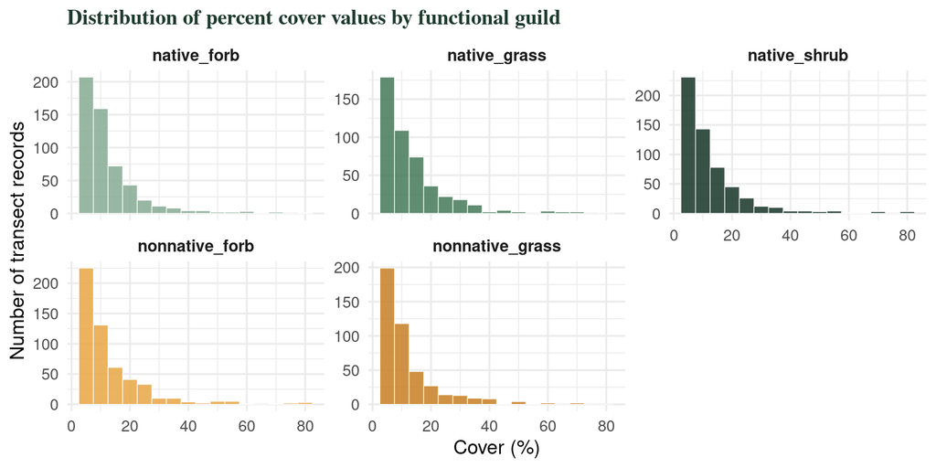

```r
ggplot(transect_data, aes(x = cover_pct, fill = guild)) +
  geom_histogram(binwidth = 5, color = "white", linewidth = 0.2, alpha = 0.88) +
  scale_fill_manual(
    values = c(
      "native_shrub"    = "#1e3a2f",
      "native_grass"    = "#4a7c5e",
      "native_forb"     = "#8aad96",
      "nonnative_grass" = "#c8832a",
      "nonnative_forb"  = "#e8a84a"
    ),
    name = "Functional guild"
  ) +
  facet_wrap(~ guild, scales = "free_y", ncol = 3) +
  labs(
    title = "Distribution of percent cover values by functional guild",
    x = "Cover (%)", y = "Number of transect records"
  ) +
  theme_minimal(base_size = 12) +
  theme(
    plot.title      = element_text(family = "serif", face = "bold",
                                   color = "#1e3a2f", size = 13),
    legend.position = "none",
    strip.text      = element_text(face = "bold", size = 10)
  )
```

**💡 Log-normal cover distributions are normal in plant ecology.** Most species are rare: a few individuals contributing little cover. A small number of dominant species contribute the bulk. This right-skewed, log-normal pattern is one of the most robust empirical regularities in community ecology (Preston 1948; McGill et al. 2007). It is why log-transformation is often applied before parametric tests on cover data.

## 3. Building the Species × Site Matrix

The **community matrix** (also called a site × species matrix) has one row per parcel and one column per species. Cell values are the summed percent cover of that species across all 20 transects. This matrix is the foundation for every analysis that follows.

### Step 1 Aggregate to parcel level

```r
# Sum cover across all transects within each parcel × species combination
parcel_cover <- transect_data %>%
  group_by(parcel_id, species) %>%
  summarise(total_cover = sum(cover_pct), .groups = "drop")

# Pivot to wide format: rows = parcels, columns = species, values = total cover
comm_wide <- parcel_cover %>%
  pivot_wider(
    names_from  = species,
    values_from = total_cover,
    values_fill = 0          # species absent from a parcel get 0
  ) %>%
  column_to_rownames("parcel_id")

dim(comm_wide)   # should be 10 parcels × up to 28 species
```

```
## [1] 10 28
```

### Step 2 Spot-check the matrix

```r
# Row sums = total cover per parcel (sum across all species)
rowSums(comm_wide) %>% sort()
```

```
##  P09  P02  P05  P03  P04  P01  P07  P06  P08  P10
## 2850 2950 2950 3190 3205 3215 3355 3405 3555 3935
```

```r
# Column sums = total cover of each species across all parcels
sort(colSums(comm_wide), decreasing = TRUE) %>% head(10)
```

```
## Artemisia californica      Nassella pulchra   Hirschfeldia incana
##                  1520                  1430                  1375
##        Sambucus nigra    Elymus condensatus     Melica imperfecta
##                  1360                  1310                  1270
##   Mimulus aurantiacus   Sisyrinchium bellum       Malosma laurina
##                  1255                  1225                  1220
##       Salix laevigata
##                  1185
```

**📌 The community matrix in `vegan`** Every function in `vegan` expects the community matrix in the format **rows = sites, columns = species**. Make sure your matrix matches this convention — it is easy to accidentally transpose it. The function `t()` can fix a transposed matrix.

### 3.1 Raw species richness per parcel

**Species richness** (*S*) is the simplest diversity measure: just a count of species present. It treats all species equally regardless of their abundance.

```r
# specnumber() from vegan counts species per site (non-zero columns per row)
richness <- tibble(
  parcel_id = rownames(comm_wide),
  S         = specnumber(comm_wide)
) %>%
  left_join(parcel_meta, by = "parcel_id")

richness %>%
  kbl(caption = "Raw species richness by parcel") %>%
  kable_styling(bootstrap_options = c("striped", "hover"), full_width = FALSE)
```

Raw species richness by parcel

| parcel_id | S | restore_age_yr | disturbance |
| --- | --- | --- | --- |
| P01 | 28 | 15 | 0.10 |
| P02 | 28 | 12 | 0.15 |
| P03 | 28 | 10 | 0.20 |
| P04 | 28 | 8 | 0.30 |
| P05 | 28 | 6 | 0.40 |
| P06 | 28 | 5 | 0.50 |
| P07 | 28 | 4 | 0.60 |
| P08 | 28 | 3 | 0.70 |
| P09 | 28 | 2 | 0.80 |
| P10 | 28 | 1 | 0.90 |

[figure not shown]

```r
ggplot(richness, aes(x = reorder(parcel_id, -S), y = S, fill = disturbance)) +
  geom_col(color = "#1e3a2f", linewidth = 0.3) +
  geom_text(aes(label = S), vjust = -0.4,
            family = "mono", size = 3.5, color = "#1e3a2f") +
  scale_fill_viridis_c(
    option = "viridis", direction = -1,
    name   = "Disturbance\nscore"
  ) +
  scale_y_continuous(expand = expansion(mult = c(0, 0.12))) +
  labs(
    title = "Raw species richness per parcel",
    subtitle = "Color indicates relative disturbance level (darker = less disturbed)",
    x = NULL, y = "Species richness (S)"
  ) +
  theme_minimal(base_size = 12) +
  theme(
    plot.title    = element_text(family = "serif", face = "bold",
                                 color = "#1e3a2f", size = 13),
    plot.subtitle = element_text(color = "#7a7a72", size = 10),
    axis.text.x   = element_text(face = "bold")
  )
```

**⚠️ Raw richness is confounded by effort.** If some parcels had more transects, or longer transects, they would detect more species simply due to greater sampling effort — not because they are genuinely more diverse. Before comparing richness across sites, we need to account for sampling effort. That is what **rarefaction** does.

## 4. Rarefaction: Accounting for Sampling Effort

**Rarefaction** asks: *if we had sampled all parcels equally intensively, how many species would we expect to find?* The algorithm repeatedly subsamples each site down to the same standardized abundance, averages the results, and produces an expected richness with a confidence interval.

E[S<sub>n</sub>] = S − Σ<sub>i=1</sub><sup>S</sup> C(N−n<sub>i</sub>, n) / C(N, n)

where N = total individuals/abundance, n = rarefied sample size, n<sub>i</sub> = abundance of species i, C() = binomial coefficient

### 4.1 Rarefaction curves for all parcels

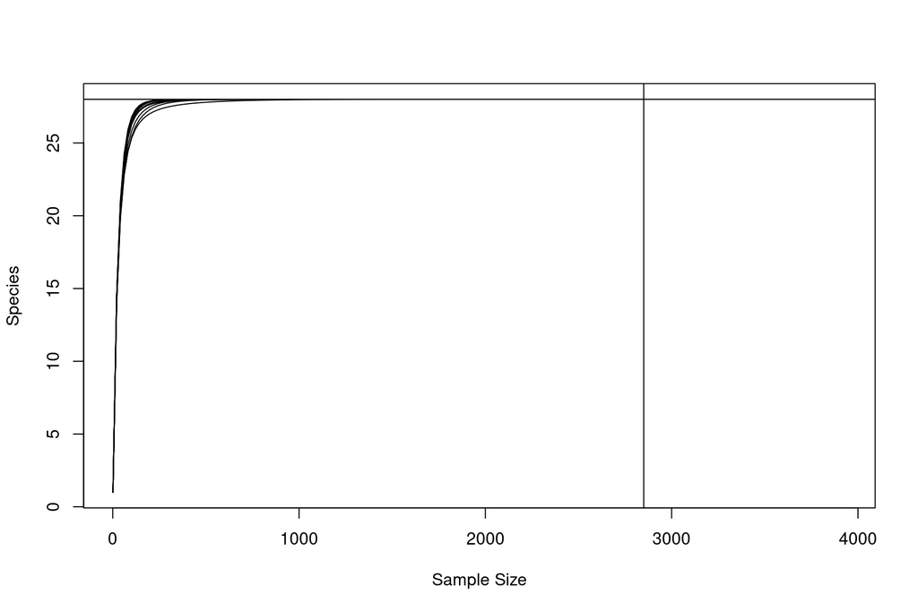

```r
# rarecurve() expects integers; round cover sums to nearest integer
comm_int <- round(comm_wide)

# Build rarefaction curves (step = 50 for smooth curves without excessive computation)
rare_list <- rarecurve(comm_int, step = 20, sample = min(rowSums(comm_int)),
                       label = FALSE, plot = FALSE)
```

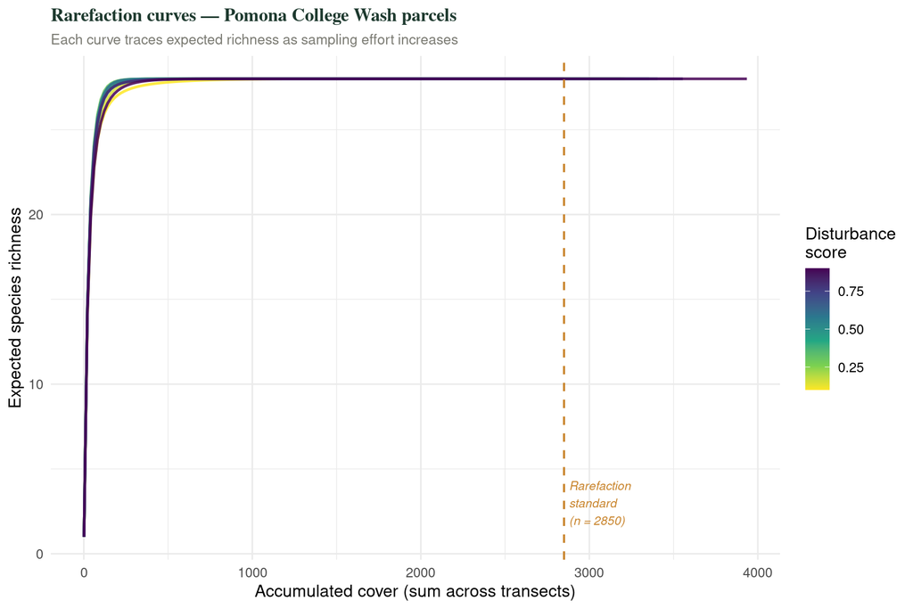

```r
# Tidy the list output into a data frame for ggplot
rare_df <- imap_dfr(rare_list, function(curve, idx) {
  tibble(
    parcel_id  = rownames(comm_int)[idx],
    abundance  = as.integer(attr(curve, "Subsample")),
    richness   = as.numeric(curve)
  )
}) %>%
  left_join(parcel_meta, by = "parcel_id")

# Vertical line at the smallest total cover (the rarefaction standard)
std_n <- min(rowSums(comm_int))

ggplot(rare_df, aes(x = abundance, y = richness,
                    color = disturbance, group = parcel_id)) +
  geom_line(linewidth = 0.9, alpha = 0.85) +
  geom_vline(xintercept = std_n, linetype = "dashed",
             color = "#c8832a", linewidth = 0.7) +
  annotate("text", x = std_n + 30, y = 3,
           label = paste0("Rarefaction\nstandard\n(n = ", std_n, ")"),
           size = 3, color = "#c8832a", hjust = 0,
           fontface = "italic") +
  scale_color_viridis_c(
    option = "viridis", direction = -1,
    name   = "Disturbance\nscore"
  ) +
  labs(
    title    = "Rarefaction curves — Pomona College Wash parcels",
    subtitle = "Each curve traces expected richness as sampling effort increases",
    x = "Accumulated cover (sum across transects)",
    y = "Expected species richness"
  ) +
  theme_minimal(base_size = 12) +
  theme(
    plot.title    = element_text(family = "serif", face = "bold",
                                 color = "#1e3a2f", size = 13),
    plot.subtitle = element_text(color = "#7a7a72", size = 10)
  )
```

**📌 Reading a rarefaction curve**

- **A steep initial slope** means many new species are discovered with each additional sampling unit — the parcel likely has high evenness.
- **A flattening plateau** means the sampling is approaching completeness for that parcel at that effort level.
- **Comparing curves at the dashed line** standardizes richness: the y-value at the dashed line is each parcel’s rarefied richness estimate.

### 4.2 Rarefied richness at the standard effort

```r
# rarefy() returns the expected richness at a single standardized sample size
rare_S <- rarefy(comm_int, sample = std_n)

tibble(
  parcel_id      = names(rare_S),
  rarefied_S     = round(as.numeric(rare_S), 1),
  raw_S          = specnumber(comm_wide)
) %>%
  left_join(parcel_meta, by = "parcel_id") %>%
  arrange(desc(rarefied_S)) %>%
  kbl(caption = paste0("Rarefied species richness at n = ", std_n,
                       " (vs. raw richness)"),
      digits = 1) %>%
  kable_styling(bootstrap_options = c("striped", "hover"), full_width = FALSE)
```

Rarefied species richness at n = 2850 (vs. raw richness)

| parcel_id | rarefied_S | raw_S | restore_age_yr | disturbance |
| --- | --- | --- | --- | --- |
| P01 | 28 | 28 | 15 | 0.1 |
| P02 | 28 | 28 | 12 | 0.1 |
| P03 | 28 | 28 | 10 | 0.2 |
| P04 | 28 | 28 | 8 | 0.3 |
| P05 | 28 | 28 | 6 | 0.4 |
| P06 | 28 | 28 | 5 | 0.5 |
| P07 | 28 | 28 | 4 | 0.6 |
| P08 | 28 | 28 | 3 | 0.7 |
| P09 | 28 | 28 | 2 | 0.8 |
| P10 | 28 | 28 | 1 | 0.9 |

## 5. Diversity Indices

Richness counts species but ignores **how evenly they are distributed**. A parcel with 20 species where one grass covers 95% of the area is less functionally diverse than a parcel where 20 species share cover roughly equally. Diversity indices capture both components.

#### Three indices you will use

- **Shannon H’** — penalizes both low richness and uneven abundances. Sensitive to rare species. Range: 0 (monoculture) to ln(S) (maximum evenness). Formula: H’ = −Σ p<sub>i</sub> ln(p<sub>i</sub>)
- **Simpson 1−D** — probability that two randomly drawn individuals belong to different species. More robust to rare species. Range: 0–1.
- **Pielou’s J (evenness)** — Shannon diversity divided by ln(S). Ranges 0–1; J = 1 means all species are equally abundant.

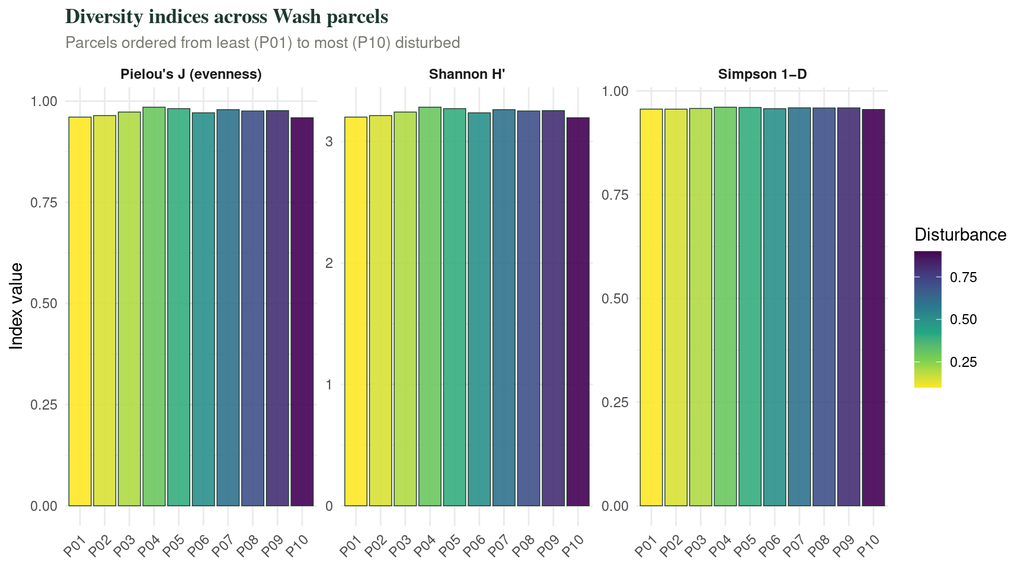

```r
div_df <- tibble(
  parcel_id = rownames(comm_wide),
  H_shannon = diversity(comm_wide, index = "shannon"),
  D_simpson = diversity(comm_wide, index = "simpson"),
  S         = specnumber(comm_wide),
  J_pielou  = H_shannon / log(S)           # Pielou's evenness
) %>%
  left_join(parcel_meta, by = "parcel_id") %>%
  pivot_longer(cols = c(H_shannon, D_simpson, J_pielou),
               names_to = "index", values_to = "value") %>%
  mutate(index = recode(index,
    "H_shannon" = "Shannon H'",
    "D_simpson" = "Simpson 1−D",
    "J_pielou"  = "Pielou's J (evenness)"
  ))

ggplot(div_df, aes(x = reorder(parcel_id, disturbance),
                   y = value, fill = disturbance)) +
  geom_col(color = "#1e3a2f", linewidth = 0.25, alpha = 0.9) +
  facet_wrap(~ index, scales = "free_y", ncol = 3) +
  scale_fill_viridis_c(option = "viridis", direction = -1,
                       name = "Disturbance") +
  scale_x_discrete(guide = guide_axis(angle = 45)) +
  labs(
    title = "Diversity indices across Wash parcels",
    subtitle = "Parcels ordered from least (P01) to most (P10) disturbed",
    x = NULL, y = "Index value"
  ) +
  theme_minimal(base_size = 11) +
  theme(
    plot.title    = element_text(family = "serif", face = "bold",
                                 color = "#1e3a2f", size = 13),
    plot.subtitle = element_text(color = "#7a7a72", size = 10),
    strip.text    = element_text(face = "bold"),
    legend.position = "right"
  )
```